# Practical Machine Learning Course Project

predmachlearn-034

triharder

November 22, 2015

# Background

Using devices such as *Jawbone Up*, *Nike FuelBand*, and *Fitbit* it is now possible to collect a large amount of data about personal activity relatively inexpensively. These type of devices are part of the quantified self movement – a group of enthusiasts who take measurements about themselves regularly to improve their health, to find patterns in their behavior, or because they are tech geeks. One thing that people regularly do is quantify how *much* of a particular activity they do, but they rarely quantify *how well they do it*. This project focuses on the data from accelerometers on the belt, forearm, arm, and dumbell of 6 participants. They were asked to perform barbell lifts correctly and incorrectly in 5 different ways. More information is available from the website [here] (http://groupware.les.inf.puc-rio.br/har) Data was extracted from the *Weight Lifting Exercise Dataset*.

# Objective

Build a model / Train an algorithm to predict the manner in which the participants did the exercise in the respective testing cases. The `classe` variable in the training set represents the manner of exercise.

# The Data

Six young health participants were asked to perform one set of 10 repetitions of the Unilateral Dumbbell Biceps Curl in five different fashions:  
- Class A - exactly according to the specification  
- Class B - throwing the elbows to the front  
- Class C - lifting the dumbbell only halfway  
- Class D - lowering the dumbbell only halfway  
- Class E - throwing the hips to the front

Class A corresponds to the specified execution of the exercise, while the other 4 classes correspond to common mistakes. Participants were supervised by an experienced weight lifter to make sure the execution complied to the manner they were supposed to simulate. The exercises were performed by six male participants aged between 20-28 years, with little weight lifting experience.

# Building a Model

## Explore data

The primary objective in exploring this data is to determine which variables to preserve for the final predictive model. Reviewing the variables summarized in `rawSumm` allows observation of which are continuous, have NAs or other invalid values, and the class of each variable which will lead us to cleaning the data to best serve our prediction model.

```r
# Consider names, str, head, summary
#names(rawData)
rawSumm <- sapply(rawData,summary)
rawSumm
```

[output not shown]

[output cut: 592 more lines]

[output not shown]

```r
#Find columns with primarily NA values for omission
trainNA <- which(sapply(rawData,function(x) {mean(is.na(x))}) > .95)
testNA <- which(sapply(testCases,function(x) {mean(is.na(x))}) > .95)
#Find columns with near zero values
nearZero <- nearZeroVar(rawData,saveMetrics=TRUE)
#Set index for prediction-irrelevant variables
trainRem <- unique(c(1,3:7,trainNA))
testRem <- unique(c(1,3:7,testNA))
all.equal(trainRem,testRem)
```

```
## [1] TRUE
```

## Clean data

Using indexes created for NA-predominant and prediction-irrelevant variables, a model data frame is created to proceed with training and fitting predictive model.

```r
modIndex <- createDataPartition(modData$classe, p = 0.60,list=FALSE)
training <- modData[modIndex,]
crossVal <- modData[-modIndex,]
```

## The Model

The `randomForest` method is chosen as a starting point for its reputation to produce a high accuracy model.

```r
rforMod <- randomForest(classe ~ ., data=training)
rforPred <- predict(rforMod, crossVal,type="class")
rf.cm <- confusionMatrix(rforPred, crossVal$classe)
rf.cm
```

```
## Confusion Matrix and Statistics
##
##           Reference
## Prediction    A    B    C    D    E
##          A 2229   13    0    0    0
##          B    2 1503    8    0    0
##          C    0    2 1356   17    3
##          D    0    0    4 1268    4
##          E    1    0    0    1 1435
##
## Overall Statistics
##
##                Accuracy : 0.993
##                  95% CI : (0.9909, 0.9947)
##     No Information Rate : 0.2845
##     P-Value [Acc > NIR] : < 2.2e-16
##
##                   Kappa : 0.9911
##  Mcnemar's Test P-Value : NA
##
## Statistics by Class:
##
##                      Class: A Class: B Class: C Class: D Class: E
## Sensitivity            0.9987   0.9901   0.9912   0.9860   0.9951
## Specificity            0.9977   0.9984   0.9966   0.9988   0.9997
## Pos Pred Value         0.9942   0.9934   0.9840   0.9937   0.9986
## Neg Pred Value         0.9995   0.9976   0.9981   0.9973   0.9989
## Prevalence             0.2845   0.1935   0.1744   0.1639   0.1838
## Detection Rate         0.2841   0.1916   0.1728   0.1616   0.1829
## Detection Prevalence   0.2858   0.1928   0.1756   0.1626   0.1832
## Balanced Accuracy      0.9982   0.9943   0.9939   0.9924   0.9974
```

```r
rfAcc <- round(rf.cm$overall['Accuracy']*100,2)
```

For completeness, an `rpart` model is also constructed for comparison.

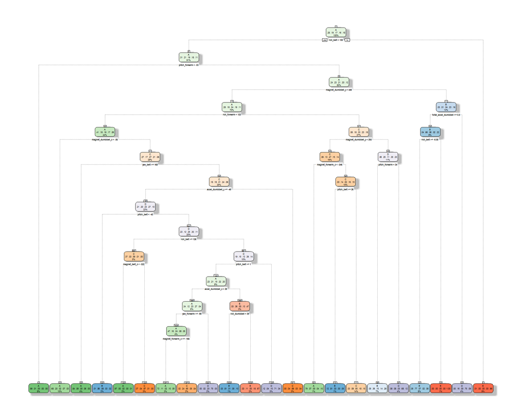

```r
rpartMod <- rpart(classe ~ ., data=training, method="class")
fancyRpartPlot(rpartMod, main = NULL, sub = NULL)
```

```r
rpartPred <- predict(rpartMod, crossVal,type="class")
rp.cm <- confusionMatrix(rpartPred, crossVal$classe)
rp.cm
```

```
## Confusion Matrix and Statistics
##
##           Reference
## Prediction    A    B    C    D    E
##          A 2006  332   36  161   57
##          B   74  921  139  106  251
##          C   60  155 1091  195  182
##          D   79   86  102  793  107
##          E   13   24    0   31  845
##
## Overall Statistics
##
##                Accuracy : 0.7209
##                  95% CI : (0.7108, 0.7308)
##     No Information Rate : 0.2845
##     P-Value [Acc > NIR] : < 2.2e-16
##
##                   Kappa : 0.6449
##  Mcnemar's Test P-Value : < 2.2e-16
##
## Statistics by Class:
##
##                      Class: A Class: B Class: C Class: D Class: E
## Sensitivity            0.8987   0.6067   0.7975   0.6166   0.5860
## Specificity            0.8956   0.9099   0.9086   0.9430   0.9894
## Pos Pred Value         0.7739   0.6177   0.6482   0.6795   0.9255
## Neg Pred Value         0.9570   0.9061   0.9551   0.9262   0.9139
## Prevalence             0.2845   0.1935   0.1744   0.1639   0.1838
## Detection Rate         0.2557   0.1174   0.1391   0.1011   0.1077
## Detection Prevalence   0.3304   0.1900   0.2145   0.1487   0.1164
## Balanced Accuracy      0.8972   0.7583   0.8531   0.7798   0.7877
```

```r
rpAcc <- round(rp.cm$overall['Accuracy']*100,2)
```

### Using Cross-Validation

A cross validation set was utilized with 40% of the original training data. The accuracy of the `randomForest` model applied to the cross-validation set is *99.3%*. The accuracy of the `rpart` model was *72.09%* comparably. All further discussion will reference the `randomForest` due to its favorable accuracy.

### Expected Out-of-Sample Error

Based on the accuracty of the random forest model which was used for prediction on the test cases, we can expect the out-of-sample error to be *0.7%*, or `1 - accuracy`.

# Prediction Summary

In closing, the random forest model yielded a highly accurate model and was applied to the test cases provided and was a clear choice over the rpart model which was only somewhat accurate.

```r
rfPred <- predict(rforMod, testData,type="class")
rpPred <- predict(rpartMod, testData,type="class")
preds <- data.frame(cbind("Case"=testCases$problem_id,"rfClasse"=as.character(rfPred),"rpClasse"=as.character(rpPred)))
```

Having verified test case predictions are correct after submission, a summary of the test case results follow with indication where the rpart model would have failed:

```
##    Case rfClasse rpClasse       Match
## 1     1        B        B         Yes
## 2     2        A        A         Yes
## 3     3        B        B         Yes
## 4     4        A        D RF Superior
## 5     5        A        A         Yes
## 6     6        E        C RF Superior
## 7     7        D        D         Yes
## 8     8        B        A RF Superior
## 9     9        A        A         Yes
## 10   10        A        A         Yes
## 11   11        B        C RF Superior
## 12   12        C        B RF Superior
## 13   13        B        C RF Superior
## 14   14        A        A         Yes
## 15   15        E        D RF Superior
## 16   16        E        E         Yes
## 17   17        A        A         Yes
## 18   18        B        A RF Superior
## 19   19        B        A RF Superior
## 20   20        B        B         Yes
```

It can be noted that there are *9* cases where the `randomForest` model is superior to the rpart model. In our 20 cases we achieved *100%* accuracy with the `randomForest` model while only *55%* of the cases were accurate with the `rpart` predictions.